# 00_Intro_PyMC slides

ECSS Miniconference 2022

An Introduction to Probabilistic Programming in Python using PyMC

Danh Phan

Linkedin: [@danhpt](https://www.linkedin.com/in/danhpt) Twitter: [@danhpt](https://twitter.com/danhpt)

Website: http://danhphan.net

Nov 2022

## 1. Introduction

### Bayes' Formula

Given two events A and B, the conditional probability of A given that B is true is expressed as follows:

$$P(A|B) = \frac{P(B|A) \times P(A)}{P(B)}$$

### Bayesian Terminology

Replacing Bayes' Formula with conventional Bayes terms:

$$P(\theta|y) = \frac{P(y|\theta) \times P(\theta)}{P(y)} = \frac{P(y|\theta) \times P(\theta)}{\int P(y|\theta)P(\theta) d\theta}$$

The equation expresses how our belief about the value of $\theta$, as expressed by the **prior distribution** $P(\theta)$ is reallocated following the observation of the data $y$, as expressed by the posterior distribution.

## 1. Introduction

### Why Bayesian Modeling?

- Conceptually transparent interpretation of probablity.
- Uncertainty quantification.
- Allows to explicitly include prior knowledge in the model.
- Felxible and suited for many applications in academia and industry.
- Scalable*

[figure not shown]

## 1. Introduction

### Why PyMC?

[figure not shown]

Learn more: [PyMC 4.0 Release Announcement](https://www.pymc.io/blog/v4_announcement.html)

## 2. Data set

**[Anscombe's quartet](https://en.wikipedia.org/wiki/Anscombe%27s_quartet)** is an interesting group of four data sets that share nearly **identical descriptive statistics** while in fact having very **different underlying relationships** between the independent and dependent variables.

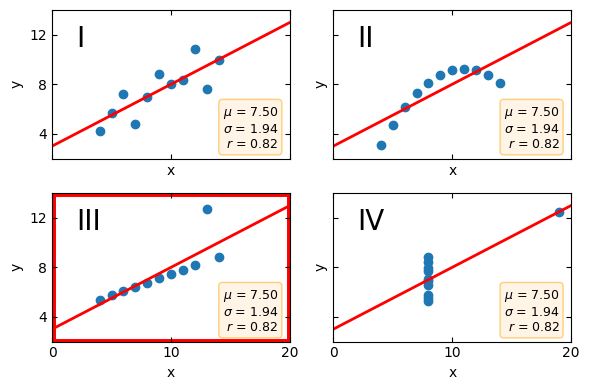

```python
plot_data()
```

## 3.1. Linear regression

We use the ordinary least squares (OLS) line to fit these data using NumPy's `polyfit`. $$y=a*x+b+ε$$

```python
a_ols, b_ols = np.polyfit(x, y, deg=1)
```

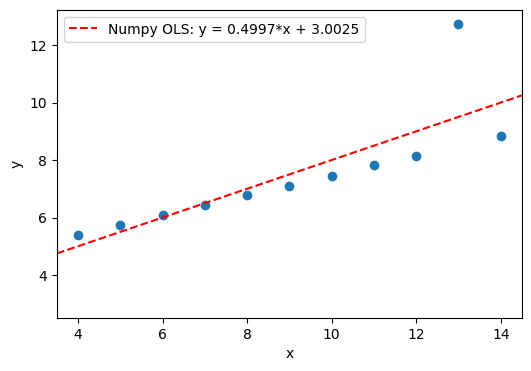

```python
plt.scatter(x, y)
plot_line(a_ols, b_ols,c='r', ls='--', label="Numpy OLS")
```

## 3.2. Robust Linear regression

```python
is_outlier = x == 13
a_robust, b_robust = np.polyfit(x[~is_outlier], y[~is_outlier], deg=1)
```

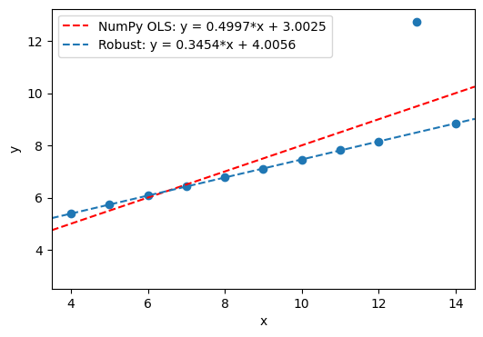

```python
plt.scatter(x, y);
plot_line(a_ols, b_ols, c='r', ls='--', label="NumPy OLS");
plot_line(a_robust, b_robust, ls='--', label="Robust");
```

## 4.1. Bayesian Linear regression

```python
with pm.Model() as ols_model:
    # Priors
    a = pm.Flat("a")
    b = pm.Flat("b")
    σ = pm.HalfFlat("σ")

    # Likelihood
    y_obs = pm.Normal("y_obs", a * x + b, σ, observed=y)

    # MCMC sampling (Default: NUTS)
    ols_trace = pm.sample(2000)
```

```
Auto-assigning NUTS sampler...
Initializing NUTS using jitter+adapt_diag...
Multiprocess sampling (4 chains in 4 jobs)
NUTS: [a, b, σ]
```

100.00% [12000/12000 00:05<00:00 Sampling 4 chains, 4 divergences]

```
Sampling 4 chains for 1_000 tune and 2_000 draw iterations (4_000 + 8_000 draws total) took 6 seconds.
```

$$y∼Normal(a*x+b,\sigma)$$

```python
pm.model_to_graphviz(ols_model)
```

[figure not shown]

### Linear regresion: Numpy vs. PyMC

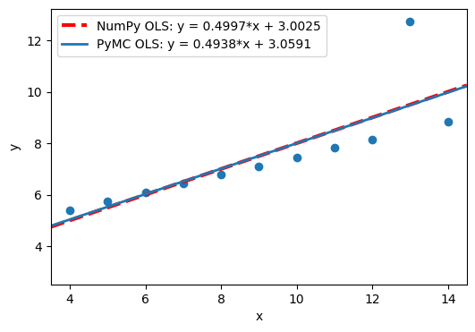

```python
plt.scatter(x, y);
plot_line(a_ols, b_ols, c='r', ls='--', label="NumPy OLS", lw=3);
plot_line(a_bays, b_bays, c='C0', label="PyMC OLS", lw=2);
```

### Linear regresion: posterior distributions

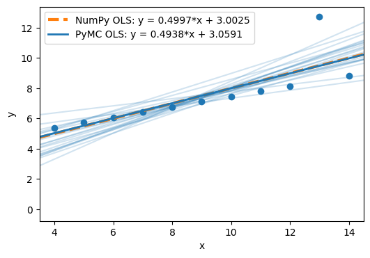

```python
plt.scatter(x, y);
plot_line(a_ols, b_ols, c='C1', ls='--', label="NumPy OLS", lw=3);
plot_line(a_bays, b_bays, c='C0', label="PyMC OLS", lw=2);
# Plot many lines from posterior distributions
for a_, b_ in (ols_trace.posterior[["a", "b"]].sel(chain=0).thin(100).to_array().T):
    plot_line(a_.values, b_.values, c='C0', alpha=0.2);
```

### Linear regresion: posterior distributions

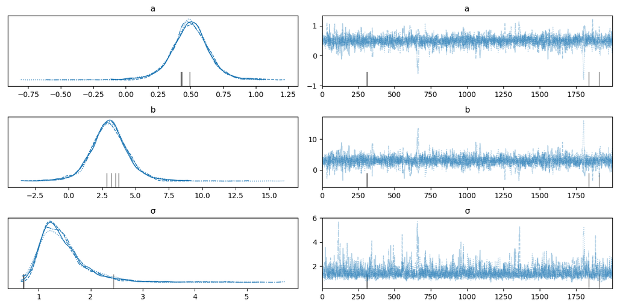

```python
az.plot_trace(ols_trace);
plt.tight_layout()
```

## 4.2. Bayesian Robust Linear regression

```python
with pm.Model() as robust_model:
    # Priors
    a = pm.Normal("a", 0, 2.5)
    b = pm.Normal("b", 0., 10)
    σ = pm.HalfNormal("σ", 2.5)
    ν = pm.Uniform("ν", 1, 10)

    # Likelihood
    y_obs = pm.StudentT("y_obs", mu=a*x + b, sigma=σ, nu=ν, observed=y)

    robust_trace = pm.sample(2000)
```

```
Auto-assigning NUTS sampler...
Initializing NUTS using jitter+adapt_diag...
Multiprocess sampling (4 chains in 4 jobs)
NUTS: [a, b, σ, ν]
```

100.00% [12000/12000 00:10<00:00 Sampling 4 chains, 0 divergences]

```
Sampling 4 chains for 1_000 tune and 2_000 draw iterations (4_000 + 8_000 draws total) took 11 seconds.
```

$$y∼StudentT(a*x+b,\sigma, \nu)$$

```python
pm.model_to_graphviz(robust_model)
```

[figure not shown]

### Robust Linear regresion: posterior distributions

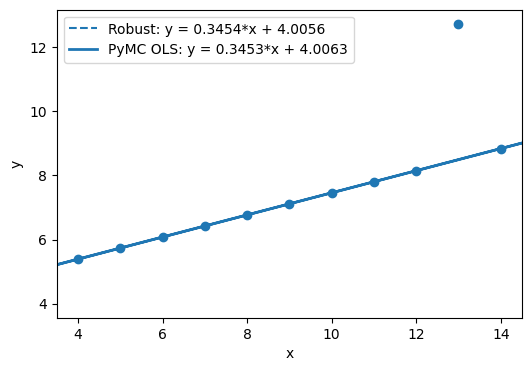

```python
plt.scatter(x, y);
plot_line(a_robust, b_robust, c='C0', ls='--', label="Robust");
plot_line(a_bays_robust, b_bays_robust, c='C0', label="PyMC OLS", lw=2);
# Plot many lines from posterior distributions
for a_, b_ in (robust_trace.posterior[["a", "b"]].sel(chain=0).thin(100).to_array().T):
    plot_line(a_.values, b_.values, c='C0', alpha=0.2);
```

### Robust Linear regresion: posterior distributions

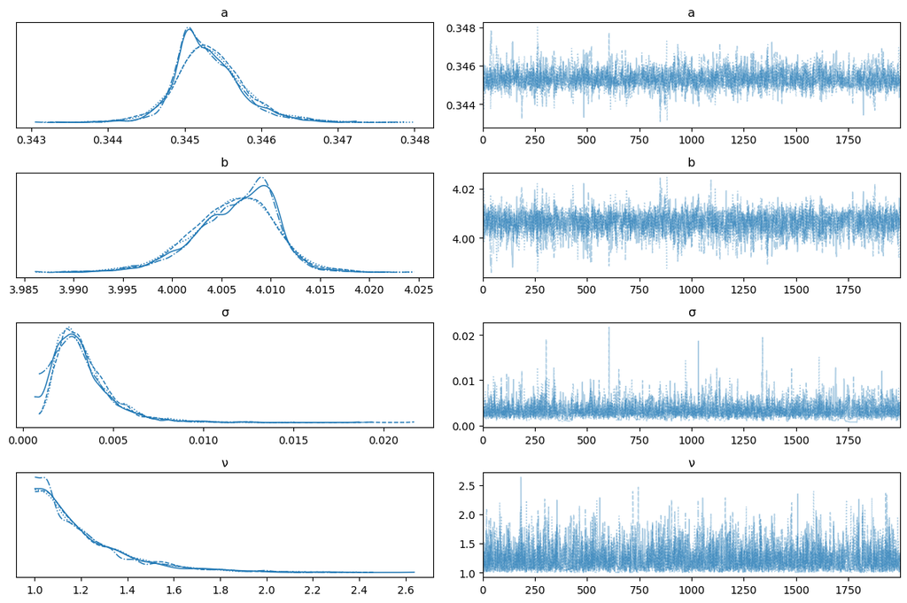

```python
az.plot_trace(robust_trace);
plt.tight_layout()
```

## 5. More on PyMC

### Examples and applications!

[figure not shown]

See PyMC Documentation: [Example Gallery](https://www.pymc.io/projects/examples/en/latest/gallery.html)

## References

### Theory

- [Statistical Rethinking](https://xcelab.net/rm/statistical-rethinking/) by Richard McElreath
- [Statistical Rethinking in PyMC](https://github.com/pymc-devs/pymc-resources/tree/main/Rethinking_2)

### PyMC

- [A Modern Introduction to Probabilistic Programming with PyMC](https://austinrochford.com/posts/intro-prob-prog-pymc.html#Robust-regression) by Austin Rochford
- PyMC [quickstart guide](https://www.pymc.io/projects/examples/en/latest/howto/api_quickstart.html), [tutorial](https://docs.pymc.io/en/latest/learn/core_notebooks/pymc_overview.html), and [example gallery](https://www.pymc.io/projects/examples/en/latest/gallery.html)
- Book: [Bayesian Analysis with Python](https://www.packtpub.com/big-data-and-business-intelligence/bayesian-analysis-python-second-edition)
- Book: [Probabilistic Programming & Bayesian Methods for Hackers](http://camdavidsonpilon.github.io/Probabilistic-Programming-and-Bayesian-Methods-for-Hackers/)
- Book: [Bayesian Modeling and Computation in Python](https://bayesiancomputationbook.com/welcome.html)

### Code

- https://github.com/danhphan/workshops